# Respondent-Information Arms: Manuscript Comparisons

Luna and Muse across five prompt arms, replicating the manuscript’s comparison families

Published

September 14, 2026

## Scope and method

The primary analysis covers **Luna** and **Muse** at N = 500, the two models carried furthest in this extension. A supplementary section repeats the same comparisons for a wider set of five models at N = 100, where every model has complete five-arm coverage but far fewer respondents.

Each cohort evaluates every model on the **same** first-N respondents of the frozen seed-42 sample, across five prompt arms:

| Arm | Information supplied |
| --- | --- |
| **D** | demographic profile only |
| **D+I** | profile plus the target-omitted ideal-point score |
| **A only** | the other 29 observed answers, no demographics |
| **D+A** | profile plus the other 29 answers |
| **D+A+I** | profile, other answers, and the score |

Comparison families follow the manuscript implementations in `Code/Boris/`: individual accuracy and PRE (`compare plus party-pre.R`), aggregate accuracy (`calculate aggregate accuracy.R`), regression weights (`regression weights.R`), rare profiles (`rare profiles.R`), and joint ideal-point fits (`evaluate-pilot-local.R`).

Two baselines recur. **PRE** is the proportional reduction in error against the pooled binary-majority rule. **Party PRE** is against each respondent’s own party’s majority on that question, estimated from the full 17,949-respondent human source rather than from the cohort.

Cohorts analysed

| Cohort | Respondents | Models | Arms | Answers |
| --- | --- | --- | --- | --- |
| Luna and Muse, N = 500 | 500 | 2 | 5 | 150000 |
| Broader model comparison, N = 100 | 100 | 5 | 5 | 75000 |

# Luna and Muse, N = 500

## Individual accuracy

**Proportional reduction in error**

Proportional reduction in error against the pooled binary-majority rule: the share of the majority rule’s errors that the model avoids. Zero means no better than always predicting the more common answer.

| Model | D | A only | D+A | D+I | D+A+I |
| --- | --- | --- | --- | --- | --- |
| Luna | 0.347 | 0.445 | 0.455 | 0.372 | 0.444 |
| Muse | 0.316 | 0.466 | 0.478 | 0.349 | 0.473 |

**D+A** performs best and **D** worst. Swapping demographics for the other answers improves it substantially. Of the gap to a perfect score left open by demographics alone, **A only** closes 19% and **D+A** closes 20%. On the measure’s own scale that is **A only** 37% better and **D+A** 41% better. Adding the ideal-point score moves it slightly on top of demographics alone and hardly at all on top of demographics-plus-answers.

**Party PRE**

The same reduction, but against each respondent’s **own party’s** majority on that question, estimated from the full 17,949-respondent human source. A negative value means the model does worse than simply applying the party stereotype.

| Model | D | A only | D+A | D+I | D+A+I |
| --- | --- | --- | --- | --- | --- |
| Luna | 0.028 | 0.174 | 0.189 | 0.065 | 0.172 |
| Muse | -0.017 | 0.206 | 0.224 | 0.031 | 0.216 |

**D+A** performs best and **D** worst. Swapping demographics for the other answers improves it substantially. Of the gap to a perfect score left open by demographics alone, **A only** closes 19% and **D+A** closes 20%. Adding the ideal-point score moves it slightly on top of demographics alone and hardly at all on top of demographics-plus-answers.

**Raw accuracy**

Share of individual answers matching the respondent’s real answer. Reported for completeness; it rewards predicting the common answer and so is less informative than PRE.

| Model | D | A only | D+A | D+I | D+A+I |
| --- | --- | --- | --- | --- | --- |
| Luna | 0.725 | 0.766 | 0.77 | 0.735 | 0.766 |
| Muse | 0.712 | 0.775 | 0.78 | 0.726 | 0.778 |

**D+A** performs best and **D** worst. Swapping demographics for the other answers improves it substantially. Of the gap to a perfect score left open by demographics alone, **A only** closes 19% and **D+A** closes 20%. On the measure’s own scale that is **A only** 7% better and **D+A** 8% better. Adding the ideal-point score moves it slightly on top of demographics alone and hardly at all on top of demographics-plus-answers.

### By party subgroup

**Party PRE within each party**

The same reduction, but against each respondent’s **own party’s** majority on that question, estimated from the full 17,949-respondent human source. A negative value means the model does worse than simply applying the party stereotype.

| Model | party | D | A only | D+A | D+I | D+A+I |
| --- | --- | --- | --- | --- | --- | --- |
| Luna | Democrat | -0.016 | 0.077 | 0.095 | -0.023 | 0.045 |
| Luna | Independent | 0.112 | 0.315 | 0.322 | 0.193 | 0.318 |
| Luna | Republican | -0.031 | 0.103 | 0.122 | -0.002 | 0.127 |
| Muse | Democrat | -0.096 | 0.067 | 0.109 | -0.127 | 0.094 |
| Muse | Independent | 0.081 | 0.334 | 0.335 | 0.190 | 0.331 |
| Muse | Republican | -0.055 | 0.195 | 0.209 | 0.002 | 0.203 |

**D+A** performs best and **D** worst. Swapping demographics for the other answers improves it substantially. Of the gap to a perfect score left open by demographics alone, **A only** closes 18% and **D+A** closes 20%. Adding the ideal-point score moves it slightly on top of demographics alone and hardly at all on top of demographics-plus-answers.

## Aggregate accuracy

**Mean absolute error in support proportion**

Aggregate accuracy: the mean absolute gap between the model’s and the survey’s support proportion, averaged over the 30 issues. This is a population-level measure, so individual errors in opposite directions cancel.

| Model | D | A only | D+A | D+I | D+A+I |
| --- | --- | --- | --- | --- | --- |
| Luna | 0.1181 | 0.0991 | 0.0897 | 0.1219 | 0.0968 |
| Muse | 0.0830 | 0.0914 | 0.0783 | 0.0942 | 0.0825 |

**D+A** performs best and **D+I** worst. Swapping demographics for the other answers improves it slightly. Of the gap to a perfect score left open by demographics alone, **A only** closes 5% and **D+A** closes 16%. Adding the ideal-point score moves it moderately on top of demographics alone and slightly on top of demographics-plus-answers.

**Majority direction correct (% of 30 issues)**

Share of the 30 issues where the model gets the majority direction right, regardless of the size of the gap.

| Model | D | A only | D+A | D+I | D+A+I |
| --- | --- | --- | --- | --- | --- |
| Luna | 86.7 | 86.7 | 90.0 | 86.7 | 80 |
| Muse | 86.7 | 76.7 | 83.3 | 83.3 | 80 |

**D** performs best and **D+A+I** worst. Swapping demographics for the other answers worsens it substantially. Of the gap to a perfect score left open by demographics alone, **A only** widens it 38% and **D+A** closes 0%. On the measure’s own scale that is **A only** 6% worse. Adding the ideal-point score moves it moderately on top of demographics alone and substantially on top of demographics-plus-answers.

**Signed aggregate bias**

Signed aggregate gap: positive means the model overstates support across issues, negative means it understates. Zero is unbiased in level, which is compatible with large offsetting errors.

| Model | D | A only | D+A | D+I | D+A+I |
| --- | --- | --- | --- | --- | --- |
| Luna | 0.0165 | -0.0098 | -0.0191 | 0.0196 | -0.0247 |
| Muse | -0.0509 | -0.0370 | -0.0314 | -0.0681 | -0.0375 |

**A only** is closest to zero and **D+I** departs from it most. Swapping demographics for the other answers improves it moderately. Of the gap to a perfect score left open by demographics alone, **A only** closes 31% and **D+A** closes 25%. Adding the ideal-point score moves it moderately on top of demographics alone and moderately on top of demographics-plus-answers.

### By party subgroup

**Aggregate mean error within each party**

Aggregate accuracy: the mean absolute gap between the model’s and the survey’s support proportion, averaged over the 30 issues. This is a population-level measure, so individual errors in opposite directions cancel.

| Model | party | D | A only | D+A | D+I | D+A+I |
| --- | --- | --- | --- | --- | --- | --- |
| Luna | Democrat | 0.1699 | 0.0914 | 0.1203 | 0.1685 | 0.1235 |
| Luna | Independent | 0.1898 | 0.1201 | 0.1126 | 0.1770 | 0.1190 |
| Luna | Republican | 0.2091 | 0.1480 | 0.1859 | 0.2199 | 0.1811 |
| Muse | Democrat | 0.1425 | 0.1035 | 0.0969 | 0.1343 | 0.0945 |
| Muse | Independent | 0.1046 | 0.1104 | 0.0940 | 0.1013 | 0.0998 |
| Muse | Republican | 0.2977 | 0.1184 | 0.1247 | 0.2732 | 0.1268 |

**A only** performs best and **D** worst. Swapping demographics for the other answers improves it substantially. Of the gap to a perfect score left open by demographics alone, **A only** closes 38% and **D+A** closes 34%. Adding the ideal-point score moves it slightly on top of demographics alone and hardly at all on top of demographics-plus-answers.

**Signed aggregate bias within each party**

Signed aggregate gap: positive means the model overstates support across issues, negative means it understates. Zero is unbiased in level, which is compatible with large offsetting errors.

| Model | party | D | A only | D+A | D+I | D+A+I |
| --- | --- | --- | --- | --- | --- | --- |
| Luna | Democrat | -0.0402 | -0.0290 | -0.0398 | -0.0459 | -0.0516 |
| Luna | Independent | 0.0539 | 0.0000 | -0.0084 | 0.0592 | -0.0126 |
| Luna | Republican | 0.0672 | 0.0106 | 0.0025 | 0.0821 | 0.0058 |
| Muse | Democrat | -0.0707 | -0.0332 | -0.0306 | -0.0848 | -0.0361 |
| Muse | Independent | -0.0066 | -0.0309 | -0.0177 | -0.0466 | -0.0238 |
| Muse | Republican | -0.0689 | -0.0503 | -0.0485 | -0.0652 | -0.0556 |

**D+A** is closest to zero and **D+I** departs from it most. Swapping demographics for the other answers improves it substantially. Of the gap to a perfect score left open by demographics alone, **A only** closes 50% and **D+A** closes 52%. Adding the ideal-point score moves it moderately on top of demographics alone and slightly on top of demographics-plus-answers.

## Ideal points

**Ideal-point mean absolute error**

Mean absolute error between each respondent’s simulated and real ideal point, from a joint human/LLM fit. This asks whether the model places a person correctly on the latent scale, not whether it gets individual items right.

| Model | D | A only | D+A | D+I | D+A+I |
| --- | --- | --- | --- | --- | --- |
| Luna | 0.776 | 0.281 | 0.422 | 0.682 | 0.421 |
| Muse | 0.862 | 0.248 | 0.296 | 0.801 | 0.320 |

**A only** performs best and **D** worst. Swapping demographics for the other answers improves it substantially. Of the gap to a perfect score left open by demographics alone, **A only** closes 68% and **D+A** closes 56%. Adding the ideal-point score moves it slightly on top of demographics alone and hardly at all on top of demographics-plus-answers.

**Correlation with the human ideal point**

Correlation between simulated and real ideal points across respondents: whether the model gets the ordering of people right, ignoring scale and offset.

| Model | D | A only | D+A | D+I | D+A+I |
| --- | --- | --- | --- | --- | --- |
| Luna | 0.719 | 0.943 | 0.905 | 0.824 | 0.918 |
| Muse | 0.715 | 0.966 | 0.955 | 0.867 | 0.956 |

**A only** performs best and **D** worst. Swapping demographics for the other answers improves it substantially. Of the gap to a perfect score left open by demographics alone, **A only** closes 84% and **D+A** closes 75%. On the measure’s own scale that is **A only** 33% better and **D+A** 30% better. Adding the ideal-point score moves it moderately on top of demographics alone and hardly at all on top of demographics-plus-answers.

**Mean signed ideal-point error**

Signed ideal-point error. Negative means the model places respondents further left than they are; positive, further right. Invisible to accuracy and PRE.

| Model | D | A only | D+A | D+I | D+A+I |
| --- | --- | --- | --- | --- | --- |
| Luna | -0.402 | -0.117 | -0.160 | -0.381 | -0.167 |
| Muse | -0.017 | -0.069 | -0.065 | -0.005 | -0.046 |

**A only** is closest to zero and **D** departs from it most. Swapping demographics for the other answers improves it substantially. Of the gap to a perfect score left open by demographics alone, **A only** closes 56% and **D+A** closes 47%. Adding the ideal-point score moves it slightly on top of demographics alone and hardly at all on top of demographics-plus-answers.

**Polarization ratio**

Polarization ratio: the simulated Democrat-Republican median gap divided by the real one. Values above 1 mean the model exaggerates the partisan divide; 1.0 would reproduce it.

| Model | D | A only | D+A | D+I | D+A+I |
| --- | --- | --- | --- | --- | --- |
| Luna | 2.77 | 1.3 | 1.74 | 2.66 | 1.72 |
| Muse | 4.56 | 1.3 | 1.49 | 4.26 | 1.52 |

**A only** comes closest to the reference value and **D** is furthest from it. Every arm overshoots it. Swapping demographics for the other answers improves it substantially. Of the gap to a perfect score left open by demographics alone, **A only** closes 89% and **D+A** closes 77%. Adding the ideal-point score moves it slightly on top of demographics alone and hardly at all on top of demographics-plus-answers.

### Deviation densities

Distribution of each respondent’s simulated minus real ideal point, by arm. A curve centred away from the dashed line places people systematically to one side; a tall narrow curve means the model compresses distinct people toward a single position.

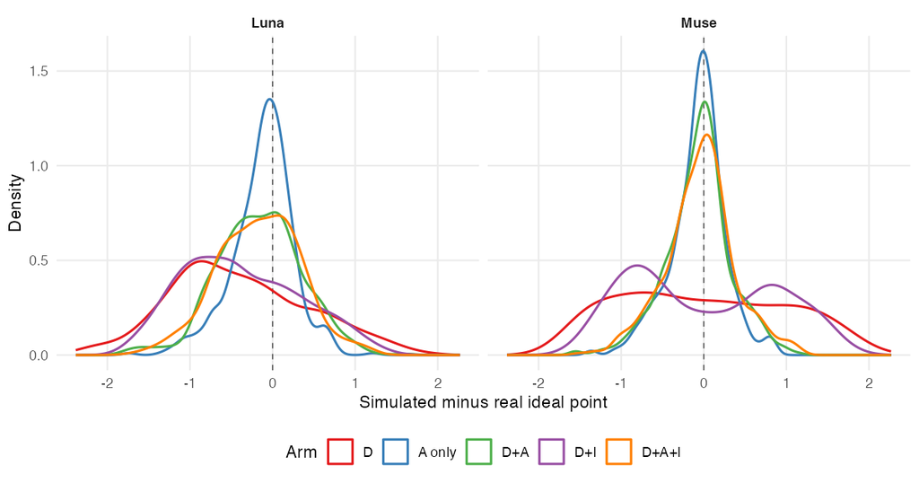

The same deviations split by the respondent’s real party, one row per arm. This is the mechanism behind the pooled signed bias: where the parties are displaced in opposite directions, a near-zero pooled figure conceals large errors in both.

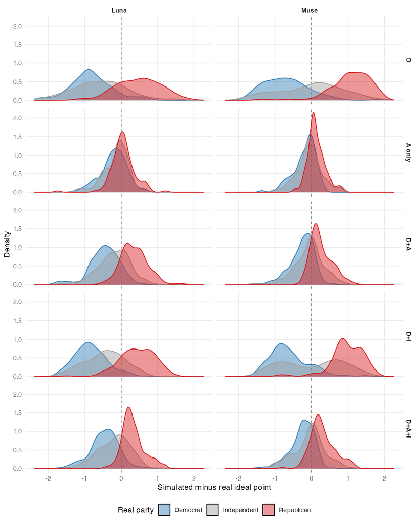

## Regression weights

**Weight differences by predictor: Luna**

Regression-weight difference per predictor: `(mean|LLM coefficient| - mean|CCES coefficient|) / mean|CCES coefficient|`. Zero means the model weights that predictor as real respondents do; +1.0 means twice the weight.

| Model | predictor | D | A only | D+A | D+I | D+A+I |
| --- | --- | --- | --- | --- | --- | --- |
| Luna | age | -0.50 | -0.17 | -0.22 | -0.49 | -0.29 |
| Luna | gender | -0.54 | 0.01 | -0.14 | -0.30 | -0.17 |
| Luna | ideology | 0.68 | 0.07 | 0.40 | 0.64 | 0.50 |
| Luna | married_dummy | 0.20 | -0.24 | 0.29 | 0.56 | 0.48 |
| Luna | pid_text | 0.68 | 0.22 | 0.41 | 0.78 | 0.34 |
| Luna | race_black | -0.38 | -0.06 | -0.11 | -0.25 | -0.04 |
| Luna | race_latino | -0.15 | 0.01 | -0.12 | -0.27 | -0.21 |
| Luna | registered_dummy | 0.20 | -0.06 | 0.13 | 0.30 | 0.08 |

**A only** comes closest to the reference value and **D+I** is furthest from it. Every arm overshoots it. Swapping demographics for the other answers improves it substantially. Of the gap to a perfect score left open by demographics alone, **A only** closes 75% and **D+A** closes 45%. Adding the ideal-point score moves it slightly on top of demographics alone and slightly on top of demographics-plus-answers.

**Weight differences by predictor: Muse**

Regression-weight difference per predictor: `(mean|LLM coefficient| - mean|CCES coefficient|) / mean|CCES coefficient|`. Zero means the model weights that predictor as real respondents do; +1.0 means twice the weight.

| Model | predictor | D | A only | D+A | D+I | D+A+I |
| --- | --- | --- | --- | --- | --- | --- |
| Muse | age | -0.51 | 0.06 | 0.05 | -0.36 | -0.02 |
| Muse | gender | -0.63 | 0.03 | -0.11 | -0.28 | -0.06 |
| Muse | ideology | 1.63 | 0.09 | 0.30 | 1.00 | 0.21 |
| Muse | married_dummy | 0.54 | 0.31 | 0.15 | 0.07 | -0.02 |
| Muse | pid_text | 0.36 | 0.12 | 0.18 | 0.69 | 0.24 |
| Muse | race_black | -0.42 | 0.11 | -0.10 | -0.26 | 0.03 |
| Muse | race_latino | -0.14 | -0.09 | 0.07 | -0.16 | 0.02 |
| Muse | registered_dummy | -0.19 | -0.05 | 0.06 | 0.41 | -0.09 |

**D+A+I** comes closest to the reference value and **D** is furthest from it. Every arm overshoots it. Swapping demographics for the other answers improves it substantially. Of the gap to a perfect score left open by demographics alone, **A only** closes 81% and **D+A** closes 77%. Adding the ideal-point score moves it moderately on top of demographics alone and slightly on top of demographics-plus-answers.

## Rare profiles

Cells are race by party with at least 20 respondents.

**Accuracy by profile**

Share of individual answers matching the respondent’s real answer. Reported for completeness; it rewards predicting the common answer and so is less informative than PRE.

| Model | cell | people | D | A only | D+A | D+I | D+A+I |
| --- | --- | --- | --- | --- | --- | --- | --- |
| Luna | Black or African-American Democrat | 41 | 0.693 | 0.724 | 0.729 | 0.690 | 0.715 |
| Luna | Hispanic or Latino Democrat | 30 | 0.742 | 0.751 | 0.764 | 0.741 | 0.749 |
| Luna | Hispanic or Latino Independent | 23 | 0.664 | 0.764 | 0.759 | 0.671 | 0.771 |
| Luna | White Democrat | 137 | 0.823 | 0.842 | 0.844 | 0.824 | 0.836 |
| Luna | White Independent | 102 | 0.696 | 0.769 | 0.779 | 0.735 | 0.776 |
| Luna | White Republican | 114 | 0.678 | 0.724 | 0.728 | 0.683 | 0.729 |
| Muse | Black or African-American Democrat | 41 | 0.671 | 0.722 | 0.723 | 0.671 | 0.729 |
| Muse | Hispanic or Latino Democrat | 30 | 0.726 | 0.748 | 0.761 | 0.694 | 0.754 |
| Muse | Hispanic or Latino Independent | 23 | 0.678 | 0.751 | 0.762 | 0.713 | 0.757 |
| Muse | White Democrat | 137 | 0.808 | 0.839 | 0.852 | 0.805 | 0.845 |
| Muse | White Independent | 102 | 0.691 | 0.776 | 0.777 | 0.732 | 0.778 |
| Muse | White Republican | 114 | 0.672 | 0.754 | 0.757 | 0.691 | 0.754 |

**D+A** performs best and **D** worst. Swapping demographics for the other answers improves it substantially. Of the gap to a perfect score left open by demographics alone, **A only** closes 18% and **D+A** closes 20%. On the measure’s own scale that is **A only** 7% better and **D+A** 8% better. Adding the ideal-point score moves it slightly on top of demographics alone and hardly at all on top of demographics-plus-answers.

**PRE against the group’s own majority**

Error reduction against **this group’s own** majority answer. Negative means the model is worse than assuming everyone in the group answers alike, which is the sharpest available test of stereotyping.

| Model | cell | people | D | A only | D+A | D+I | D+A+I |
| --- | --- | --- | --- | --- | --- | --- | --- |
| Luna | Black or African-American Democrat | 41 | -0.167 | -0.050 | -0.031 | -0.180 | -0.087 |
| Luna | Hispanic or Latino Democrat | 30 | -0.084 | -0.047 | 0.009 | -0.089 | -0.056 |
| Luna | Hispanic or Latino Independent | 23 | 0.072 | 0.348 | 0.336 | 0.092 | 0.368 |
| Luna | White Democrat | 137 | -0.001 | 0.103 | 0.116 | 0.000 | 0.069 |
| Luna | White Independent | 102 | 0.143 | 0.347 | 0.377 | 0.253 | 0.370 |
| Luna | White Republican | 114 | -0.069 | 0.083 | 0.096 | -0.053 | 0.099 |
| Muse | Black or African-American Democrat | 41 | -0.254 | -0.059 | -0.056 | -0.254 | -0.031 |
| Muse | Hispanic or Latino Democrat | 30 | -0.154 | -0.061 | -0.005 | -0.285 | -0.033 |
| Muse | Hispanic or Latino Independent | 23 | 0.112 | 0.312 | 0.344 | 0.208 | 0.328 |
| Muse | White Democrat | 137 | -0.090 | 0.088 | 0.160 | -0.108 | 0.123 |
| Muse | White Independent | 102 | 0.128 | 0.370 | 0.371 | 0.245 | 0.373 |
| Muse | White Republican | 114 | -0.089 | 0.181 | 0.191 | -0.026 | 0.183 |

**D+A** performs best and **D** worst. Swapping demographics for the other answers improves it substantially. Of the gap to a perfect score left open by demographics alone, **A only** closes 17% and **D+A** closes 19%. Adding the ideal-point score moves it slightly on top of demographics alone and slightly on top of demographics-plus-answers.

**Between-person SD ratio**

Between-person spread the model reproduces within a group, as a fraction of the real spread. Values below 1 mean it makes group members more alike than they are.

| Model | cell | people | D | A only | D+A | D+I | D+A+I |
| --- | --- | --- | --- | --- | --- | --- | --- |
| Luna | Black or African-American Democrat | 41 | 0.332 | 0.577 | 0.392 | 0.378 | 0.402 |
| Luna | Hispanic or Latino Democrat | 30 | 0.329 | 0.690 | 0.520 | 0.508 | 0.661 |
| Luna | Hispanic or Latino Independent | 23 | 0.433 | 0.607 | 0.700 | 0.534 | 0.443 |
| Luna | White Democrat | 137 | 0.304 | 0.572 | 0.479 | 0.381 | 0.449 |
| Luna | White Independent | 102 | 0.590 | 0.733 | 0.686 | 0.621 | 0.588 |
| Luna | White Republican | 114 | 0.562 | 0.722 | 0.570 | 0.449 | 0.462 |
| Muse | Black or African-American Democrat | 41 | 0.358 | 0.753 | 0.694 | 0.413 | 0.718 |
| Muse | Hispanic or Latino Democrat | 30 | 0.405 | 0.913 | 0.871 | 0.387 | 0.808 |
| Muse | Hispanic or Latino Independent | 23 | 0.341 | 0.830 | 0.891 | 0.407 | 0.887 |
| Muse | White Democrat | 137 | 0.447 | 0.762 | 0.678 | 0.304 | 0.590 |
| Muse | White Independent | 102 | 0.858 | 1.002 | 1.022 | 0.602 | 0.965 |
| Muse | White Republican | 114 | 0.310 | 0.829 | 0.766 | 0.330 | 0.776 |

**A only** comes closest to the reference value and **D** is furthest from it. Every arm falls short of it. Swapping demographics for the other answers improves it substantially. Of the gap to a perfect score left open by demographics alone, **A only** closes 55% and **D+A** closes 45%. Adding the ideal-point score moves it hardly at all on top of demographics alone and slightly on top of demographics-plus-answers.

**Issue-profile correlation**

Correlation between the group’s real and simulated issue profile: whether the model knows *which* issues this group supports.

| Model | cell | people | D | A only | D+A | D+I | D+A+I |
| --- | --- | --- | --- | --- | --- | --- | --- |
| Luna | Black or African-American Democrat | 41 | 0.835 | 0.793 | 0.825 | 0.836 | 0.843 |
| Luna | Hispanic or Latino Democrat | 30 | 0.853 | 0.851 | 0.839 | 0.857 | 0.846 |
| Luna | Hispanic or Latino Independent | 23 | 0.576 | 0.609 | 0.633 | 0.543 | 0.683 |
| Luna | White Democrat | 137 | 0.953 | 0.954 | 0.962 | 0.955 | 0.959 |
| Luna | White Independent | 102 | 0.807 | 0.732 | 0.810 | 0.817 | 0.797 |
| Luna | White Republican | 114 | 0.818 | 0.779 | 0.845 | 0.795 | 0.845 |
| Muse | Black or African-American Democrat | 41 | 0.837 | 0.778 | 0.822 | 0.832 | 0.813 |
| Muse | Hispanic or Latino Democrat | 30 | 0.819 | 0.752 | 0.778 | 0.803 | 0.774 |
| Muse | Hispanic or Latino Independent | 23 | 0.655 | 0.579 | 0.631 | 0.630 | 0.600 |
| Muse | White Democrat | 137 | 0.937 | 0.932 | 0.945 | 0.906 | 0.937 |
| Muse | White Independent | 102 | 0.585 | 0.721 | 0.746 | 0.643 | 0.750 |
| Muse | White Republican | 114 | 0.762 | 0.817 | 0.849 | 0.802 | 0.849 |

**D+A+I** performs best and **A only** worst. Swapping demographics for the other answers worsens it moderately. Of the gap to a perfect score left open by demographics alone, **A only** widens it 6% and **D+A** closes 10%. On the measure’s own scale that is **A only** 1% worse and **D+A** 3% better. Adding the ideal-point score makes little difference, either on its own or on top of the answers.

# Supplementary: broader model comparison

# Broader model comparison, N = 100

## Individual accuracy

**Proportional reduction in error**

Proportional reduction in error against the pooled binary-majority rule: the share of the majority rule’s errors that the model avoids. Zero means no better than always predicting the more common answer.

| Model | D | A only | D+A | D+I | D+A+I |
| --- | --- | --- | --- | --- | --- |
| GPT-OSS | 0.229 | 0.364 | 0.318 | 0.220 | 0.313 |
| Glimmer | 0.262 | 0.368 | 0.375 | 0.268 | 0.396 |
| Luna | 0.318 | 0.433 | 0.450 | 0.333 | 0.450 |
| Muse | 0.266 | 0.445 | 0.454 | 0.301 | 0.446 |
| Phi-4 | 0.259 | 0.342 | 0.385 | 0.273 | 0.337 |

**D+A** performs best and **D** worst. Swapping demographics for the other answers improves it substantially. Of the gap to a perfect score left open by demographics alone, **A only** closes 17% and **D+A** closes 18%. On the measure’s own scale that is **A only** 46% better and **D+A** 49% better. Adding the ideal-point score moves it slightly on top of demographics alone and hardly at all on top of demographics-plus-answers.

**Party PRE**

The same reduction, but against each respondent’s **own party’s** majority on that question, estimated from the full 17,949-respondent human source. A negative value means the model does worse than simply applying the party stereotype.

| Model | D | A only | D+A | D+I | D+A+I |
| --- | --- | --- | --- | --- | --- |
| GPT-OSS | -0.103 | 0.090 | 0.024 | -0.116 | 0.017 |
| Glimmer | -0.056 | 0.096 | 0.106 | -0.047 | 0.137 |
| Luna | 0.024 | 0.189 | 0.213 | 0.045 | 0.213 |
| Muse | -0.050 | 0.206 | 0.219 | 0.000 | 0.207 |
| Phi-4 | -0.060 | 0.059 | 0.120 | -0.039 | 0.052 |

**D+A** performs best and **D** worst. Swapping demographics for the other answers improves it substantially. Of the gap to a perfect score left open by demographics alone, **A only** closes 17% and **D+A** closes 18%. Adding the ideal-point score moves it slightly on top of demographics alone and hardly at all on top of demographics-plus-answers.

**Raw accuracy**

Share of individual answers matching the respondent’s real answer. Reported for completeness; it rewards predicting the common answer and so is less informative than PRE.

| Model | D | A only | D+A | D+I | D+A+I |
| --- | --- | --- | --- | --- | --- |
| GPT-OSS | 0.682 | 0.738 | 0.719 | 0.679 | 0.717 |
| Glimmer | 0.696 | 0.740 | 0.743 | 0.698 | 0.751 |
| Luna | 0.719 | 0.766 | 0.773 | 0.725 | 0.773 |
| Muse | 0.698 | 0.771 | 0.775 | 0.712 | 0.772 |
| Phi-4 | 0.695 | 0.729 | 0.747 | 0.701 | 0.727 |

**D+A** performs best and **D** worst. Swapping demographics for the other answers improves it substantially. Of the gap to a perfect score left open by demographics alone, **A only** closes 17% and **D+A** closes 18%. On the measure’s own scale that is **A only** 7% better and **D+A** 8% better. Adding the ideal-point score moves it slightly on top of demographics alone and hardly at all on top of demographics-plus-answers.

### By party subgroup

**Party PRE within each party**

The same reduction, but against each respondent’s **own party’s** majority on that question, estimated from the full 17,949-respondent human source. A negative value means the model does worse than simply applying the party stereotype.

| Model | party | D | A only | D+A | D+I | D+A+I |
| --- | --- | --- | --- | --- | --- | --- |
| GPT-OSS | Democrat | -0.229 | -0.112 | -0.054 | -0.240 | -0.101 |
| GPT-OSS | Independent | 0.110 | 0.355 | 0.244 | 0.081 | 0.267 |
| GPT-OSS | Republican | -0.260 | -0.057 | -0.187 | -0.252 | -0.195 |
| Glimmer | Democrat | -0.186 | -0.074 | -0.050 | -0.202 | -0.050 |
| Glimmer | Independent | 0.140 | 0.369 | 0.360 | 0.169 | 0.369 |
| Glimmer | Republican | -0.183 | -0.095 | -0.073 | -0.179 | 0.015 |
| Luna | Democrat | -0.070 | 0.128 | 0.155 | -0.093 | 0.078 |
| Luna | Independent | 0.160 | 0.358 | 0.378 | 0.203 | 0.413 |
| Luna | Republican | -0.061 | 0.027 | 0.053 | -0.027 | 0.084 |
| Muse | Democrat | -0.182 | 0.089 | 0.097 | -0.213 | 0.085 |
| Muse | Independent | 0.122 | 0.392 | 0.401 | 0.230 | 0.416 |
| Muse | Republican | -0.145 | 0.076 | 0.099 | -0.092 | 0.053 |
| Phi-4 | Democrat | -0.167 | -0.128 | -0.035 | -0.174 | -0.039 |
| Phi-4 | Independent | 0.099 | 0.314 | 0.337 | 0.157 | 0.265 |
| Phi-4 | Republican | -0.164 | -0.092 | -0.011 | -0.164 | -0.137 |

**D+A** performs best and **D** worst. Swapping demographics for the other answers improves it substantially. Of the gap to a perfect score left open by demographics alone, **A only** closes 16% and **D+A** closes 17%. Adding the ideal-point score moves it slightly on top of demographics alone and hardly at all on top of demographics-plus-answers.

## Aggregate accuracy

**Mean absolute error in support proportion**

Aggregate accuracy: the mean absolute gap between the model’s and the survey’s support proportion, averaged over the 30 issues. This is a population-level measure, so individual errors in opposite directions cancel.

| Model | D | A only | D+A | D+I | D+A+I |
| --- | --- | --- | --- | --- | --- |
| GPT-OSS | 0.1523 | 0.1407 | 0.1683 | 0.1513 | 0.1743 |
| Glimmer | 0.1327 | 0.1443 | 0.1433 | 0.1330 | 0.1353 |
| Luna | 0.1090 | 0.1063 | 0.0940 | 0.1230 | 0.0987 |
| Muse | 0.1003 | 0.1027 | 0.0970 | 0.1073 | 0.0990 |
| Phi-4 | 0.1227 | 0.1557 | 0.1333 | 0.1260 | 0.1570 |

**Majority direction correct (% of 30 issues)**

Share of the 30 issues where the model gets the majority direction right, regardless of the size of the gap.

| Model | D | A only | D+A | D+I | D+A+I |
| --- | --- | --- | --- | --- | --- |
| GPT-OSS | 73.3 | 80.0 | 73.3 | 63.3 | 73.3 |
| Glimmer | 80.0 | 80.0 | 80.0 | 70.0 | 83.3 |
| Luna | 86.7 | 83.3 | 86.7 | 83.3 | 80.0 |
| Muse | 80.0 | 76.7 | 86.7 | 73.3 | 80.0 |
| Phi-4 | 73.3 | 73.3 | 80.0 | 63.3 | 76.7 |

**D+A** performs best and **D+I** worst. Swapping demographics for the other answers barely matters. Of the gap to a perfect score left open by demographics alone, **A only** closes 0% and **D+A** closes 12%. On the measure’s own scale that is **D+A** 3% better. Adding the ideal-point score moves it substantially on top of demographics alone and slightly on top of demographics-plus-answers.

**Signed aggregate bias**

Signed aggregate gap: positive means the model overstates support across issues, negative means it understates. Zero is unbiased in level, which is compatible with large offsetting errors.

| Model | D | A only | D+A | D+I | D+A+I |
| --- | --- | --- | --- | --- | --- |
| GPT-OSS | -0.1290 | -0.0953 | -0.1410 | -0.1253 | -0.1497 |
| Glimmer | -0.1133 | -0.1183 | -0.1233 | -0.1083 | -0.1180 |
| Luna | 0.0003 | -0.0177 | -0.0300 | 0.0170 | -0.0347 |
| Muse | -0.0677 | -0.0507 | -0.0503 | -0.0840 | -0.0503 |
| Phi-4 | -0.0907 | -0.0563 | -0.0787 | -0.1020 | -0.1110 |

**A only** is closest to zero and **D+A+I** departs from it most. Swapping demographics for the other answers improves it moderately. Of the gap to a perfect score left open by demographics alone, **A only** closes 16% and **D+A** widens it 6%. Adding the ideal-point score moves it moderately on top of demographics alone and moderately on top of demographics-plus-answers.

### By party subgroup

**Aggregate mean error within each party**

Aggregate accuracy: the mean absolute gap between the model’s and the survey’s support proportion, averaged over the 30 issues. This is a population-level measure, so individual errors in opposite directions cancel.

| Model | party | D | A only | D+A | D+I | D+A+I |
| --- | --- | --- | --- | --- | --- | --- |
| GPT-OSS | Democrat | 0.1833 | 0.1373 | 0.1397 | 0.1794 | 0.1476 |
| GPT-OSS | Independent | 0.1762 | 0.1548 | 0.2024 | 0.1762 | 0.2024 |
| GPT-OSS | Republican | 0.3067 | 0.1789 | 0.2611 | 0.3022 | 0.2656 |
| Glimmer | Democrat | 0.1873 | 0.1389 | 0.1468 | 0.1921 | 0.1484 |
| Glimmer | Independent | 0.1738 | 0.1679 | 0.1595 | 0.1524 | 0.1583 |
| Glimmer | Republican | 0.3222 | 0.2011 | 0.2278 | 0.3300 | 0.2067 |
| Luna | Democrat | 0.1587 | 0.0992 | 0.1127 | 0.1635 | 0.1254 |
| Luna | Independent | 0.2250 | 0.1440 | 0.1381 | 0.2071 | 0.1405 |
| Luna | Republican | 0.2000 | 0.1478 | 0.1822 | 0.2144 | 0.1844 |
| Muse | Democrat | 0.1325 | 0.1087 | 0.1024 | 0.1548 | 0.1048 |
| Muse | Independent | 0.1357 | 0.1417 | 0.1333 | 0.1464 | 0.1393 |
| Muse | Republican | 0.2956 | 0.1467 | 0.1556 | 0.2756 | 0.1644 |
| Phi-4 | Democrat | 0.2087 | 0.1770 | 0.1659 | 0.2040 | 0.1698 |
| Phi-4 | Independent | 0.2048 | 0.1762 | 0.1714 | 0.1738 | 0.1821 |
| Phi-4 | Republican | 0.2900 | 0.1800 | 0.1922 | 0.2967 | 0.2178 |

**A only** performs best and **D** worst. Swapping demographics for the other answers improves it substantially. Of the gap to a perfect score left open by demographics alone, **A only** closes 28% and **D+A** closes 22%. Adding the ideal-point score makes little difference, either on its own or on top of the answers.

**Signed aggregate bias within each party**

Signed aggregate gap: positive means the model overstates support across issues, negative means it understates. Zero is unbiased in level, which is compatible with large offsetting errors.

| Model | party | D | A only | D+A | D+I | D+A+I |
| --- | --- | --- | --- | --- | --- | --- |
| GPT-OSS | Democrat | -0.1214 | -0.0754 | -0.1032 | -0.1127 | -0.1175 |
| GPT-OSS | Independent | -0.0952 | -0.0833 | -0.1333 | -0.1024 | -0.1381 |
| GPT-OSS | Republican | -0.1711 | -0.1344 | -0.2011 | -0.1644 | -0.2056 |
| Glimmer | Democrat | -0.1127 | -0.1008 | -0.1024 | -0.1079 | -0.1071 |
| Glimmer | Independent | -0.0976 | -0.0964 | -0.0952 | -0.0857 | -0.0917 |
| Glimmer | Republican | -0.1289 | -0.1633 | -0.1789 | -0.1300 | -0.1578 |
| Luna | Democrat | -0.0444 | -0.0310 | -0.0476 | -0.0524 | -0.0524 |
| Luna | Independent | 0.0750 | -0.0036 | -0.0071 | 0.0833 | -0.0119 |
| Luna | Republican | -0.0067 | -0.0122 | -0.0267 | 0.0522 | -0.0311 |
| Muse | Democrat | -0.0817 | -0.0357 | -0.0405 | -0.0960 | -0.0397 |
| Muse | Independent | -0.0071 | -0.0440 | -0.0286 | -0.0512 | -0.0274 |
| Muse | Republican | -0.1044 | -0.0778 | -0.0844 | -0.0978 | -0.0867 |
| Phi-4 | Democrat | -0.1040 | -0.0976 | -0.0817 | -0.1056 | -0.1016 |
| Phi-4 | Independent | -0.0667 | -0.0167 | -0.0548 | -0.0929 | -0.0964 |
| Phi-4 | Republican | -0.0944 | -0.0356 | -0.0967 | -0.1056 | -0.1378 |

**A only** is closest to zero and **D+I** departs from it most. Swapping demographics for the other answers improves it substantially. Of the gap to a perfect score left open by demographics alone, **A only** closes 23% and **D+A** closes 2%. Adding the ideal-point score moves it moderately on top of demographics alone and moderately on top of demographics-plus-answers.

## Ideal points

**Ideal-point mean absolute error**

Mean absolute error between each respondent’s simulated and real ideal point, from a joint human/LLM fit. This asks whether the model places a person correctly on the latent scale, not whether it gets individual items right.

| Model | D | A only | D+A | D+I | D+A+I |
| --- | --- | --- | --- | --- | --- |
| GPT-OSS | 0.871 | 0.270 | 0.458 | 0.879 | 0.473 |
| Glimmer | 0.939 | 0.311 | 0.426 | 0.960 | 0.451 |
| Luna | 0.730 | 0.283 | 0.393 | 0.623 | 0.412 |
| Muse | 0.879 | 0.292 | 0.302 | 0.831 | 0.331 |
| Phi-4 | 0.893 | 0.378 | 0.469 | 0.909 | 0.501 |

**A only** performs best and **D** worst. Swapping demographics for the other answers improves it substantially. Of the gap to a perfect score left open by demographics alone, **A only** closes 64% and **D+A** closes 53%. Adding the ideal-point score makes little difference, either on its own or on top of the answers.

**Correlation with the human ideal point**

Correlation between simulated and real ideal points across respondents: whether the model gets the ordering of people right, ignoring scale and offset.

| Model | D | A only | D+A | D+I | D+A+I |
| --- | --- | --- | --- | --- | --- |
| GPT-OSS | 0.718 | 0.938 | 0.900 | 0.751 | 0.903 |
| Glimmer | 0.710 | 0.942 | 0.921 | 0.784 | 0.912 |
| Luna | 0.707 | 0.938 | 0.918 | 0.829 | 0.918 |
| Muse | 0.711 | 0.954 | 0.955 | 0.845 | 0.946 |
| Phi-4 | 0.690 | 0.913 | 0.903 | 0.726 | 0.898 |

**A only** performs best and **D** worst. Swapping demographics for the other answers improves it substantially. Of the gap to a perfect score left open by demographics alone, **A only** closes 78% and **D+A** closes 72%. On the measure’s own scale that is **A only** 32% better and **D+A** 30% better. Adding the ideal-point score moves it moderately on top of demographics alone and hardly at all on top of demographics-plus-answers.

**Mean signed ideal-point error**

Signed ideal-point error. Negative means the model places respondents further left than they are; positive, further right. Invisible to accuracy and PRE.

| Model | D | A only | D+A | D+I | D+A+I |
| --- | --- | --- | --- | --- | --- |
| GPT-OSS | -0.095 | 0.042 | 0.052 | -0.099 | 0.062 |
| Glimmer | 0.063 | 0.078 | 0.039 | 0.044 | 0.021 |
| Luna | -0.280 | -0.066 | -0.099 | -0.285 | -0.096 |
| Muse | 0.146 | 0.014 | 0.001 | 0.128 | 0.060 |
| Phi-4 | -0.183 | -0.131 | -0.121 | -0.111 | -0.057 |

**D+A+I** is closest to zero and **D** departs from it most. Swapping demographics for the other answers improves it substantially. Of the gap to a perfect score left open by demographics alone, **A only** closes 57% and **D+A** closes 59%. Adding the ideal-point score moves it slightly on top of demographics alone and hardly at all on top of demographics-plus-answers.

**Polarization ratio**

Polarization ratio: the simulated Democrat-Republican median gap divided by the real one. Values above 1 mean the model exaggerates the partisan divide; 1.0 would reproduce it.

| Model | D | A only | D+A | D+I | D+A+I |
| --- | --- | --- | --- | --- | --- |
| GPT-OSS | 4.28 | 1.16 | 2.02 | 4.70 | 2.00 |
| Glimmer | 5.63 | 1.46 | 1.81 | 5.78 | 2.02 |
| Luna | 3.10 | 1.21 | 1.64 | 2.47 | 1.74 |
| Muse | 4.78 | 1.39 | 1.44 | 4.60 | 1.46 |
| Phi-4 | 4.45 | 1.45 | 2.02 | 4.98 | 2.12 |

**A only** comes closest to the reference value and **D+I** is furthest from it. Every arm overshoots it. Swapping demographics for the other answers improves it substantially. Of the gap to a perfect score left open by demographics alone, **A only** closes 90% and **D+A** closes 77%. Adding the ideal-point score makes little difference, either on its own or on top of the answers.

### Deviation densities

Distribution of each respondent’s simulated minus real ideal point, by arm. A curve centred away from the dashed line places people systematically to one side; a tall narrow curve means the model compresses distinct people toward a single position.

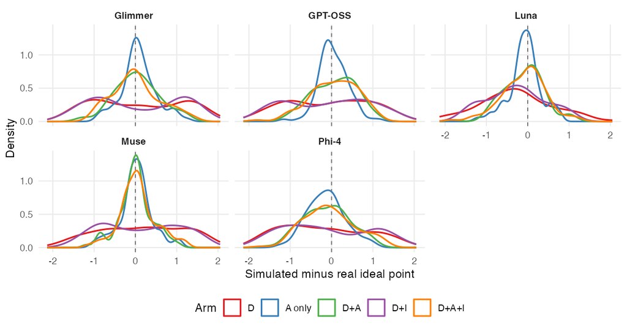

The same deviations split by the respondent’s real party, one row per arm. This is the mechanism behind the pooled signed bias: where the parties are displaced in opposite directions, a near-zero pooled figure conceals large errors in both.

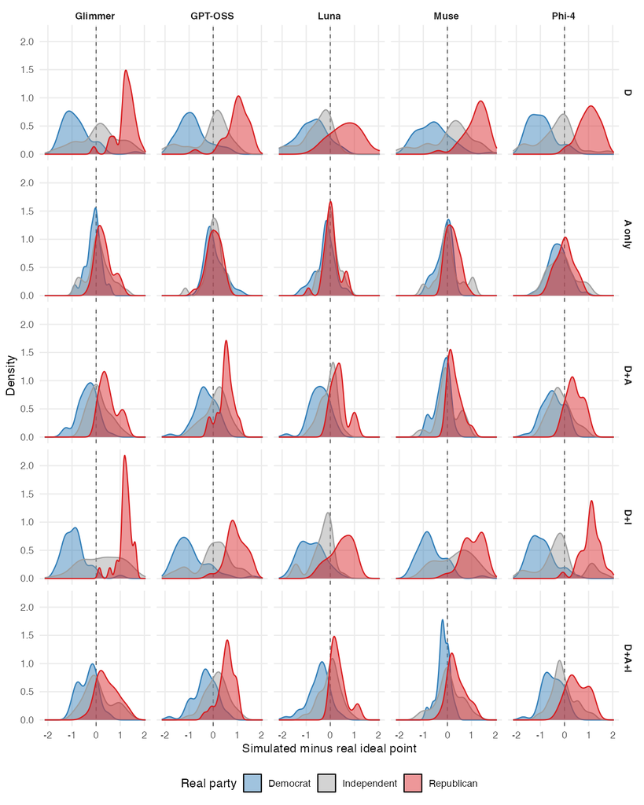

## Regression weights

**Weight differences by predictor: Glimmer**

Regression-weight difference per predictor: `(mean|LLM coefficient| - mean|CCES coefficient|) / mean|CCES coefficient|`. Zero means the model weights that predictor as real respondents do; +1.0 means twice the weight.

| Model | predictor | D | A only | D+A | D+I | D+A+I |
| --- | --- | --- | --- | --- | --- | --- |
| Glimmer | age | -0.75 | 0.02 | 0.07 | -0.65 | 0.10 |
| Glimmer | gender | -0.41 | -0.13 | -0.27 | -0.54 | -0.34 |
| Glimmer | ideology | 1.51 | 0.16 | 0.40 | 1.22 | 0.35 |
| Glimmer | married_dummy | -0.68 | 0.04 | -0.17 | -0.51 | -0.14 |
| Glimmer | pid_text | 0.75 | 0.24 | 0.49 | 0.96 | 0.43 |
| Glimmer | race_black | -0.51 | 0.07 | 0.18 | -0.33 | 0.11 |
| Glimmer | race_latino | -0.29 | -0.25 | -0.12 | -0.53 | -0.22 |
| Glimmer | registered_dummy | -0.74 | -0.13 | -0.12 | -0.68 | -0.18 |

**A only** comes closest to the reference value and **D** is furthest from it. Every arm overshoots it. Swapping demographics for the other answers improves it substantially. Of the gap to a perfect score left open by demographics alone, **A only** closes 82% and **D+A** closes 68%. Adding the ideal-point score makes little difference, either on its own or on top of the answers.

**Weight differences by predictor: GPT-OSS**

Regression-weight difference per predictor: `(mean|LLM coefficient| - mean|CCES coefficient|) / mean|CCES coefficient|`. Zero means the model weights that predictor as real respondents do; +1.0 means twice the weight.

| Model | predictor | D | A only | D+A | D+I | D+A+I |
| --- | --- | --- | --- | --- | --- | --- |
| GPT-OSS | age | -0.71 | -0.23 | -0.30 | -0.65 | -0.30 |
| GPT-OSS | gender | -0.42 | -0.07 | -0.30 | -0.62 | -0.35 |
| GPT-OSS | ideology | 1.37 | 0.09 | 0.58 | 1.56 | 0.57 |
| GPT-OSS | married_dummy | -0.44 | 0.06 | -0.16 | -0.51 | -0.21 |
| GPT-OSS | pid_text | 0.68 | 0.05 | 0.34 | 0.50 | 0.34 |
| GPT-OSS | race_black | -0.46 | 0.07 | 0.11 | -0.51 | -0.11 |
| GPT-OSS | race_latino | -0.47 | -0.23 | -0.23 | -0.52 | -0.35 |
| GPT-OSS | registered_dummy | -0.67 | -0.02 | -0.10 | -0.59 | -0.36 |

**A only** comes closest to the reference value and **D+I** is furthest from it. Every arm overshoots it. Swapping demographics for the other answers improves it substantially. Of the gap to a perfect score left open by demographics alone, **A only** closes 84% and **D+A** closes 59%. Adding the ideal-point score moves it hardly at all on top of demographics alone and slightly on top of demographics-plus-answers.

**Weight differences by predictor: Luna**

Regression-weight difference per predictor: `(mean|LLM coefficient| - mean|CCES coefficient|) / mean|CCES coefficient|`. Zero means the model weights that predictor as real respondents do; +1.0 means twice the weight.

| Model | predictor | D | A only | D+A | D+I | D+A+I |
| --- | --- | --- | --- | --- | --- | --- |
| Luna | age | -0.25 | -0.04 | -0.08 | -0.19 | -0.19 |
| Luna | gender | -0.44 | -0.12 | -0.44 | -0.34 | -0.41 |
| Luna | ideology | 0.63 | 0.10 | 0.42 | 0.63 | 0.55 |
| Luna | married_dummy | -0.19 | -0.02 | -0.14 | -0.48 | -0.07 |
| Luna | pid_text | 0.76 | 0.13 | 0.41 | 0.54 | 0.39 |
| Luna | race_black | -0.41 | -0.07 | -0.23 | -0.46 | -0.11 |
| Luna | race_latino | -0.32 | -0.02 | -0.13 | -0.38 | -0.31 |
| Luna | registered_dummy | -0.74 | -0.11 | -0.28 | -0.56 | -0.12 |

**A only** comes closest to the reference value and **D** is furthest from it. Every arm overshoots it. Swapping demographics for the other answers improves it substantially. Of the gap to a perfect score left open by demographics alone, **A only** closes 84% and **D+A** closes 43%. Adding the ideal-point score makes little difference, either on its own or on top of the answers.

**Weight differences by predictor: Muse**

Regression-weight difference per predictor: `(mean|LLM coefficient| - mean|CCES coefficient|) / mean|CCES coefficient|`. Zero means the model weights that predictor as real respondents do; +1.0 means twice the weight.

| Model | predictor | D | A only | D+A | D+I | D+A+I |
| --- | --- | --- | --- | --- | --- | --- |
| Muse | age | -0.65 | -0.08 | 0.05 | -0.66 | -0.09 |
| Muse | gender | -0.54 | -0.16 | -0.19 | -0.61 | -0.13 |
| Muse | ideology | 1.86 | 0.13 | 0.23 | 1.07 | 0.25 |
| Muse | married_dummy | -0.39 | 0.06 | -0.05 | -0.25 | -0.14 |
| Muse | pid_text | 0.21 | 0.12 | 0.28 | 0.77 | 0.33 |
| Muse | race_black | -0.50 | 0.10 | 0.15 | -0.06 | 0.06 |
| Muse | race_latino | -0.45 | -0.11 | -0.03 | -0.35 | -0.07 |
| Muse | registered_dummy | -0.61 | -0.19 | -0.12 | -0.54 | -0.18 |

**A only** comes closest to the reference value and **D** is furthest from it. Every arm overshoots it. Swapping demographics for the other answers improves it substantially. Of the gap to a perfect score left open by demographics alone, **A only** closes 82% and **D+A** closes 79%. Adding the ideal-point score moves it slightly on top of demographics alone and hardly at all on top of demographics-plus-answers.

**Weight differences by predictor: Phi-4**

Regression-weight difference per predictor: `(mean|LLM coefficient| - mean|CCES coefficient|) / mean|CCES coefficient|`. Zero means the model weights that predictor as real respondents do; +1.0 means twice the weight.

| Model | predictor | D | A only | D+A | D+I | D+A+I |
| --- | --- | --- | --- | --- | --- | --- |
| Phi-4 | age | -0.53 | -0.12 | -0.13 | -0.54 | -0.11 |
| Phi-4 | gender | -0.45 | -0.35 | -0.46 | -0.35 | -0.56 |
| Phi-4 | ideology | 0.51 | 0.33 | 0.50 | 0.82 | 0.57 |
| Phi-4 | married_dummy | -0.47 | 0.03 | -0.23 | -0.48 | -0.31 |
| Phi-4 | pid_text | 1.35 | -0.03 | 0.48 | 1.10 | 0.52 |
| Phi-4 | race_black | -0.64 | -0.08 | -0.18 | -0.50 | -0.10 |
| Phi-4 | race_latino | -0.27 | -0.25 | -0.19 | -0.32 | 0.08 |
| Phi-4 | registered_dummy | -0.69 | -0.28 | -0.30 | -0.63 | -0.35 |

**A only** comes closest to the reference value and **D** is furthest from it. Every arm overshoots it. Swapping demographics for the other answers improves it substantially. Of the gap to a perfect score left open by demographics alone, **A only** closes 70% and **D+A** closes 50%. Adding the ideal-point score makes little difference, either on its own or on top of the answers.

## Rare profiles

Cells are race by party with at least 20 respondents.

**Accuracy by profile**

Share of individual answers matching the respondent’s real answer. Reported for completeness; it rewards predicting the common answer and so is less informative than PRE.

| Model | cell | people | D | A only | D+A | D+I | D+A+I |
| --- | --- | --- | --- | --- | --- | --- | --- |
| GPT-OSS | White Democrat | 22 | 0.797 | 0.797 | 0.820 | 0.798 | 0.811 |
| GPT-OSS | White Republican | 23 | 0.667 | 0.707 | 0.674 | 0.670 | 0.671 |
| Glimmer | White Democrat | 22 | 0.802 | 0.814 | 0.820 | 0.797 | 0.821 |
| Glimmer | White Republican | 23 | 0.696 | 0.700 | 0.707 | 0.691 | 0.733 |
| Luna | White Democrat | 22 | 0.823 | 0.862 | 0.859 | 0.818 | 0.844 |
| Luna | White Republican | 23 | 0.712 | 0.739 | 0.745 | 0.713 | 0.746 |
| Muse | White Democrat | 22 | 0.800 | 0.835 | 0.850 | 0.792 | 0.842 |
| Muse | White Republican | 23 | 0.703 | 0.752 | 0.758 | 0.701 | 0.735 |
| Phi-4 | White Democrat | 22 | 0.803 | 0.794 | 0.835 | 0.802 | 0.826 |
| Phi-4 | White Republican | 23 | 0.699 | 0.701 | 0.729 | 0.699 | 0.683 |

**D+A** performs best and **D+I** worst. Swapping demographics for the other answers improves it substantially. Of the gap to a perfect score left open by demographics alone, **A only** closes 8% and **D+A** closes 12%. On the measure’s own scale that is **A only** 3% better and **D+A** 4% better. Adding the ideal-point score moves it hardly at all on top of demographics alone and moderately on top of demographics-plus-answers.

**PRE against the group’s own majority**

Error reduction against **this group’s own** majority answer. Negative means the model is worse than assuming everyone in the group answers alike, which is the sharpest available test of stereotyping.

| Model | cell | people | D | A only | D+A | D+I | D+A+I |
| --- | --- | --- | --- | --- | --- | --- | --- |
| GPT-OSS | White Democrat | 22 | -0.252 | -0.252 | -0.112 | -0.243 | -0.168 |
| GPT-OSS | White Republican | 23 | -0.278 | -0.122 | -0.250 | -0.267 | -0.261 |
| Glimmer | White Democrat | 22 | -0.224 | -0.150 | -0.112 | -0.252 | -0.103 |
| Glimmer | White Republican | 23 | -0.167 | -0.150 | -0.122 | -0.183 | -0.022 |
| Luna | White Democrat | 22 | -0.093 | 0.150 | 0.131 | -0.121 | 0.037 |
| Luna | White Republican | 23 | -0.106 | 0.000 | 0.022 | -0.100 | 0.028 |
| Muse | White Democrat | 22 | -0.234 | -0.019 | 0.075 | -0.280 | 0.028 |
| Muse | White Republican | 23 | -0.139 | 0.050 | 0.072 | -0.144 | -0.017 |
| Phi-4 | White Democrat | 22 | -0.215 | -0.271 | -0.019 | -0.224 | -0.075 |
| Phi-4 | White Republican | 23 | -0.156 | -0.144 | -0.039 | -0.156 | -0.217 |

**D+A** performs best and **D+I** worst. Swapping demographics for the other answers improves it moderately. Of the gap to a perfect score left open by demographics alone, **A only** closes 8% and **D+A** closes 13%. Adding the ideal-point score moves it hardly at all on top of demographics alone and moderately on top of demographics-plus-answers.

**Between-person SD ratio**

Between-person spread the model reproduces within a group, as a fraction of the real spread. Values below 1 mean it makes group members more alike than they are.

| Model | cell | people | D | A only | D+A | D+I | D+A+I |
| --- | --- | --- | --- | --- | --- | --- | --- |
| GPT-OSS | White Democrat | 22 | 0.357 | 0.536 | 0.693 | 0.347 | 0.623 |
| GPT-OSS | White Republican | 23 | 0.271 | 0.873 | 0.452 | 0.302 | 0.485 |
| Glimmer | White Democrat | 22 | 0.263 | 0.514 | 0.638 | 0.235 | 0.514 |
| Glimmer | White Republican | 23 | 0.060 | 0.800 | 0.633 | 0.084 | 0.776 |
| Luna | White Democrat | 22 | 0.425 | 0.693 | 0.730 | 0.531 | 0.564 |
| Luna | White Republican | 23 | 0.715 | 0.571 | 0.517 | 0.517 | 0.391 |
| Muse | White Democrat | 22 | 0.521 | 0.561 | 0.536 | 0.339 | 0.522 |
| Muse | White Republican | 23 | 0.359 | 0.889 | 0.715 | 0.275 | 0.791 |
| Phi-4 | White Democrat | 22 | 0.187 | 0.434 | 0.319 | 0.239 | 0.702 |
| Phi-4 | White Republican | 23 | 0.257 | 0.468 | 0.435 | 0.141 | 0.578 |

**A only** comes closest to the reference value and **D+I** is furthest from it. Every arm falls short of it. Swapping demographics for the other answers improves it substantially. Of the gap to a perfect score left open by demographics alone, **A only** closes 44% and **D+A** closes 34%. Adding the ideal-point score moves it slightly on top of demographics alone and slightly on top of demographics-plus-answers.

**Issue-profile correlation**

Correlation between the group’s real and simulated issue profile: whether the model knows *which* issues this group supports.

| Model | cell | people | D | A only | D+A | D+I | D+A+I |
| --- | --- | --- | --- | --- | --- | --- | --- |
| GPT-OSS | White Democrat | 22 | 0.889 | 0.901 | 0.915 | 0.869 | 0.901 |
| GPT-OSS | White Republican | 23 | 0.690 | 0.729 | 0.724 | 0.720 | 0.704 |
| Glimmer | White Democrat | 22 | 0.881 | 0.862 | 0.897 | 0.874 | 0.886 |
| Glimmer | White Republican | 23 | 0.731 | 0.736 | 0.774 | 0.717 | 0.802 |
| Luna | White Democrat | 22 | 0.945 | 0.945 | 0.957 | 0.955 | 0.951 |
| Luna | White Republican | 23 | 0.834 | 0.802 | 0.836 | 0.792 | 0.836 |
| Muse | White Democrat | 22 | 0.930 | 0.917 | 0.935 | 0.896 | 0.926 |
| Muse | White Republican | 23 | 0.760 | 0.815 | 0.828 | 0.772 | 0.819 |
| Phi-4 | White Democrat | 22 | 0.885 | 0.812 | 0.880 | 0.878 | 0.879 |
| Phi-4 | White Republican | 23 | 0.776 | 0.757 | 0.822 | 0.751 | 0.742 |

**D+A** performs best and **D+I** worst. Swapping demographics for the other answers worsens it slightly. Of the gap to a perfect score left open by demographics alone, **A only** widens it 3% and **D+A** closes 15%. On the measure’s own scale that is **A only** 1% worse and **D+A** 3% better. Adding the ideal-point score moves it moderately on top of demographics alone and moderately on top of demographics-plus-answers.

# Limitations